# Frequency of face to face and phone contacts with friends

# 1 Description of DataSchema variable

The description of harmonised variable is the following:

- Short name: `f_cont_fr`
- Variable label: `Frequency of face to face and phone contacts with friends`
- Variable description: `Frequency of contacts with friends, face to face or by phone`
- Domain: `Social environment`
- Value type: `categorical`
- Category coding:

| **Code** | **Category Label** |
| --- | --- |
| 1 | Daily/Almost daily |
| 2 | Once a week |
| 3 | Once or few times a month |
| 4 | Less than once a month |
| 5 | Never/No friends |

- Category missings:

| **Code** | **Category Label** |
| --- | --- |
| 991 | CAPI/interviewer error |
| 992 | Impute |
| 993 | Disable to measure |
| 994 | Not attempt/not done |
| 995 | Does not answer |
| 996 | Not applicable |
| 997 | Refuse |
| 998 | Do not know |
| 999 | Missing |

# 2 Data process

## 2.1 England

### 2.1.1 Wave 1

#### 2.1.1.1 Study-specific variable description

| **Name** | `scfrd` | `scfrdg` |
| --- | --- | --- |
| **Label** | `do you have any friends` | `How often the respondent meets up with their friends` |
| **Table name** | `wave_1_core_data_v3` | `wave_1_core_data_v3` |
| **Categories** | `1 = Yes` `2 = No` | `1 = Three or more times a week` `2 = Once or twice a week` `3 = Once or twice a month` `4 = Every few months` `5 = Once or twice a year` `6 = Less than once a year or never` |
| **Missings** | `-9 = Not answered` `-1 = Item not applicable` | `-9 = Not answered` `-1 = Item not applicable` |
| **Description** |  |  |

scfrd

| Sample size | Missing values |
| --- | --- |
| 12099 | 1484 |

Type of missing

|  | -9 | -1 | NA |
| --- | --- | --- | --- |
| Frequency | 376.00 | 1108.00 | 0 |
| Percentage | 3.11 | 9.16 | 0 |

Category

|  | 1 | 2 |
| --- | --- | --- |
| Frequency | 10041.00 | 574.00 |
| Percentage | 82.99 | 4.74 |

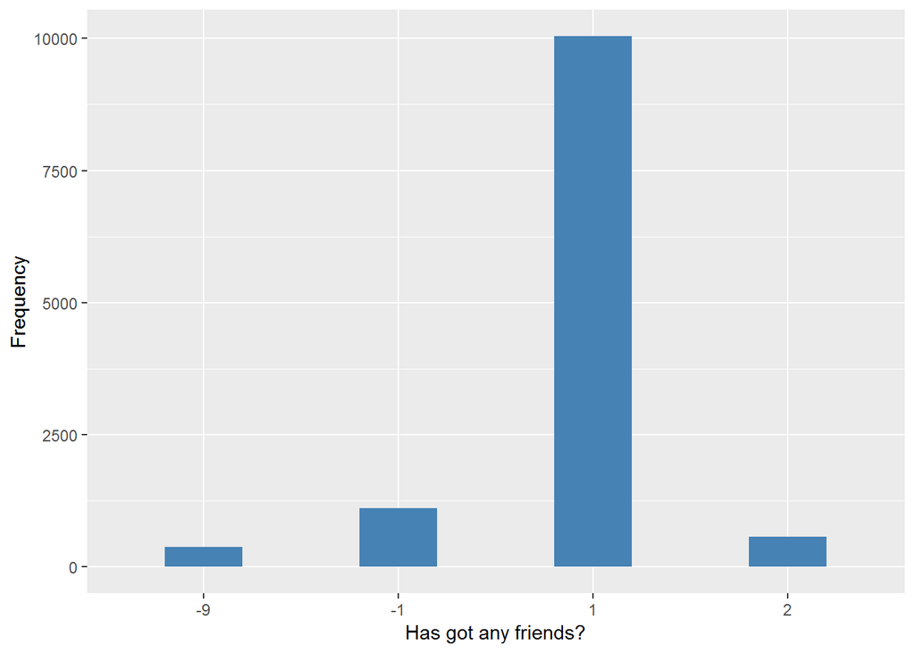

scfrdg

| Sample size | Missing values |
| --- | --- |
| 12099 | 2263 |

Type of missing

|  | -9 | -1 | NA |
| --- | --- | --- | --- |
| Frequency | 205.00 | 2058.00 | 0 |
| Percentage | 1.69 | 17.01 | 0 |

Category

|  | 1 | 2 | 3 | 4 | 5 | 6 |
| --- | --- | --- | --- | --- | --- | --- |
| Frequency | 1646.0 | 4176.00 | 2434.00 | 1056.00 | 356.00 | 168.00 |
| Percentage | 13.6 | 34.52 | 20.12 | 8.73 | 2.94 | 1.39 |

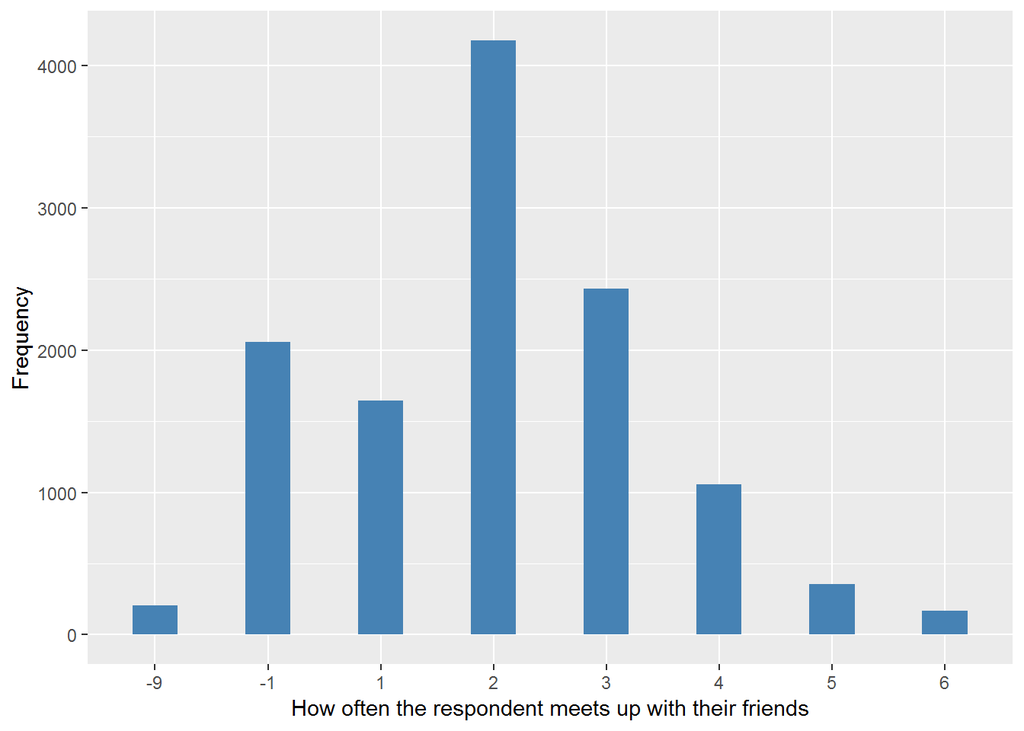

#### 2.1.1.2 Harmonisation algorithm

To compute the harmonize variable from the study-specific variable it has to be recoded as follows:

- `if scfrdg=1 then 1`
- `if scfrdg=2 then 2`
- `if scfrdg=3 then 3`
- `if scfrdg=4 or 5 then 4`
- `if scfrd=2 or scfrdg=6 then 5`
- `-9 into 995`
- `-1 into 996`
- `NA into 999`

**R script:**

```r
ELSA_ds_w1 <- tibble(id = ELSA_w1$id)

ELSA_w1$scfrd <- car::recode(as.vector(ELSA_w1$scfrd), "NA='-999'")
ELSA_w1$scfrdg <- car::recode(as.vector(ELSA_w1$scfrdg), "NA='-999'")

ELSA_ds_w1$f_cont_fr <- c(NA)  # I think it is required
for (i in 1:dim(ELSA_w1)[1]) {
    if (ELSA_w1$scfrdg[i] == 1) {
        ELSA_ds_w1$f_cont_fr[i] = 1
    } else if (ELSA_w1$scfrdg[i] == 2) {
        ELSA_ds_w1$f_cont_fr[i] = 2
    } else if (ELSA_w1$scfrdg[i] == 3) {
        ELSA_ds_w1$f_cont_fr[i] = 3
    } else if (ELSA_w1$scfrdg[i] %in% c(4, 5)) {
        ELSA_ds_w1$f_cont_fr[i] = 4
    } else if (ELSA_w1$scfrdg[i] == 6 | ELSA_w1$scfrd[i] == 2) {
        ELSA_ds_w1$f_cont_fr[i] = 5
    } else if (ELSA_w1$scfrdg[i] == -9 | ELSA_w1$scfrd[i] == -9) {
        ELSA_ds_w1$f_cont_fr[i] = 995
    } else if (ELSA_w1$scfrdg[i] == -1 | ELSA_w1$scfrd[i] == -1) {
        ELSA_ds_w1$f_cont_fr[i] = 996
    }
}

ELSA_ds_w1$f_cont_fr <- car::recode(as.vector(ELSA_ds_w1$f_cont_fr), "NA='999'")
ELSA_ds_w1$f_cont_fr <- labelled(ELSA_ds_w1$f_cont_fr, labels = c(`Daily/Almost daily` = 1,
    `Once a week` = 2, `Once or few times a month` = 3, `Less than once a month` = 4,
    `Never/No friends` = 5, Missing = 999, `Do not know` = 998, Refuse = 997,
    `Not applicable` = 996, `Don't answer` = 995, `Not attempt/not done/not yet recorded` = 994,
    `Disable to measure` = 993, Impute = 992, `CAPI/interviewer error` = 991))
```

#### 2.1.1.3 Statistics of the new harmonised variable

Frequency of face to face and phone contacts with friends

| Sample size | Missing values |
| --- | --- |
| 12099 | 1689 |

Category

|  | 1 | 2 | 3 | 4 | 5 |
| --- | --- | --- | --- | --- | --- |
| Frequency | 1646.0 | 4176.00 | 2434.00 | 1412.00 | 742.00 |
| Percentage | 13.6 | 34.52 | 20.12 | 11.67 | 6.13 |

Type of missing

|  | 991 | 992 | 993 | 994 | 995 | 996 | 997 | 998 | 999 | NA |
| --- | --- | --- | --- | --- | --- | --- | --- | --- | --- | --- |
| Frequency | 0 | 0 | 0 | 0 | 581.0 | 1108.00 | 0 | 0 | 0 | 0 |
| Percentage | 0 | 0 | 0 | 0 | 4.8 | 9.16 | 0 | 0 | 0 | 0 |

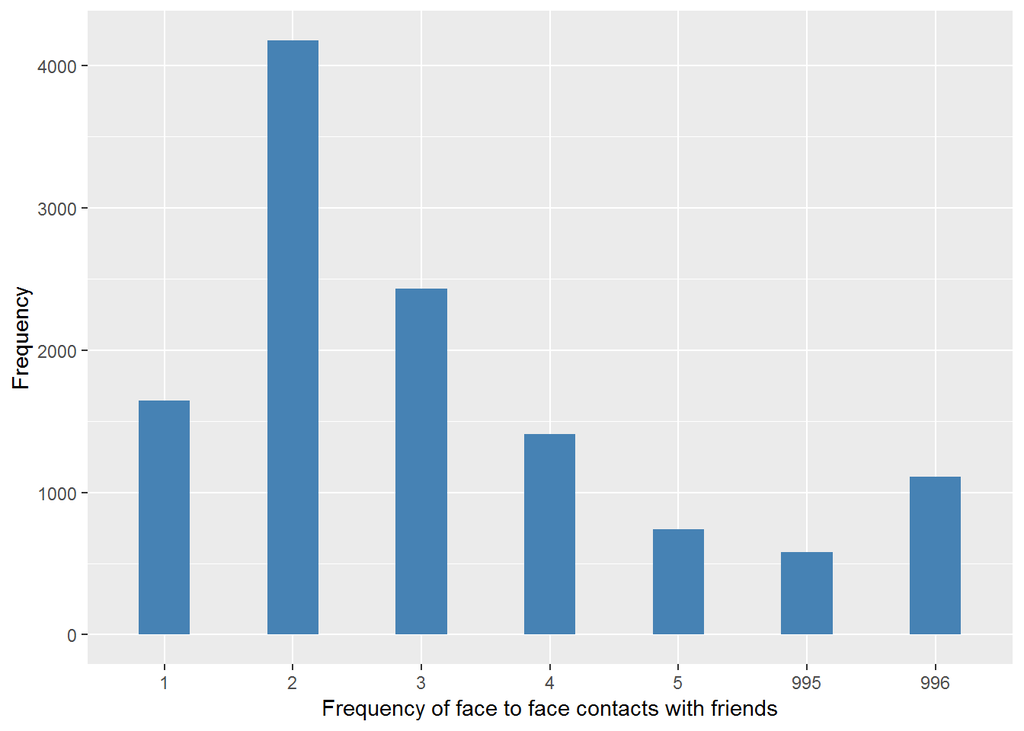

#### 2.1.1.4 Validation

### 2.1.2 Wave 2

#### 2.1.2.1 Study-specific variable description

| **Name** | `scfrd` | `scfrdg` |
| --- | --- | --- |
| **Label** | `do you have any friends` | `How often the respondent meets up with their friends` |
| **Table name** | `wave_2_core_data_v4` | `wave_2_core_data_v4` |
| **Categories** | `1 = Yes` `2 = No` | `1 = Three or more times a week` `2 = Once or twice a week` `3 = Once or twice a month` `4 = Every few months` `5 = Once or twice a year` `6 = Less than once a year or never` |
| **Missings** | `-9 = Not answered` `-1 = Item not applicable` | `-9 = Not answered` `-1 = Item not applicable` |
| **Description** |  |  |

scfrd

| Sample size | Missing values |
| --- | --- |
| 9432 | 1186 |

Type of missing

|  | -9 | -1 | NA |
| --- | --- | --- | --- |
| Frequency | 114.00 | 1072.00 | 0 |
| Percentage | 1.21 | 11.37 | 0 |

Category

|  | 1 | 2 |
| --- | --- | --- |
| Frequency | 7857.0 | 389.00 |
| Percentage | 83.3 | 4.12 |

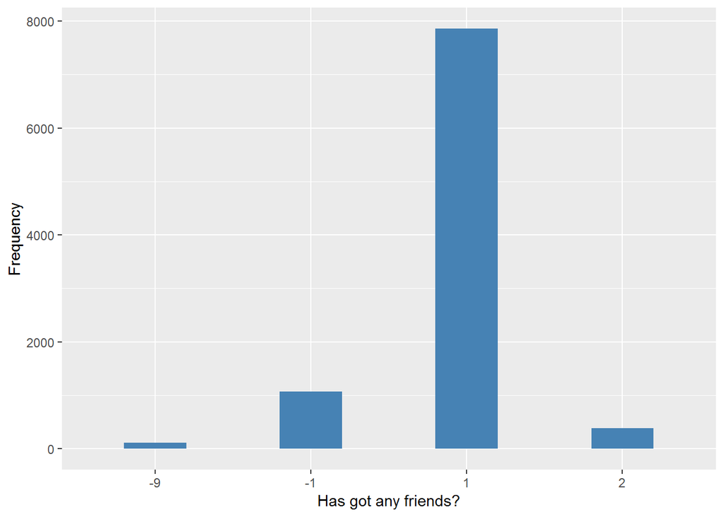

scfrdg

| Sample size | Missing values |
| --- | --- |
| 9432 | 1712 |

Type of missing

|  | -9 | -1 | NA |
| --- | --- | --- | --- |
| Frequency | 137.00 | 1575.0 | 0 |
| Percentage | 1.45 | 16.7 | 0 |

Category

|  | 1 | 2 | 3 | 4 | 5 | 6 |
| --- | --- | --- | --- | --- | --- | --- |
| Frequency | 1204.00 | 3141.0 | 2077.00 | 873.00 | 283 | 142.00 |
| Percentage | 12.77 | 33.3 | 22.02 | 9.26 | 3 | 1.51 |

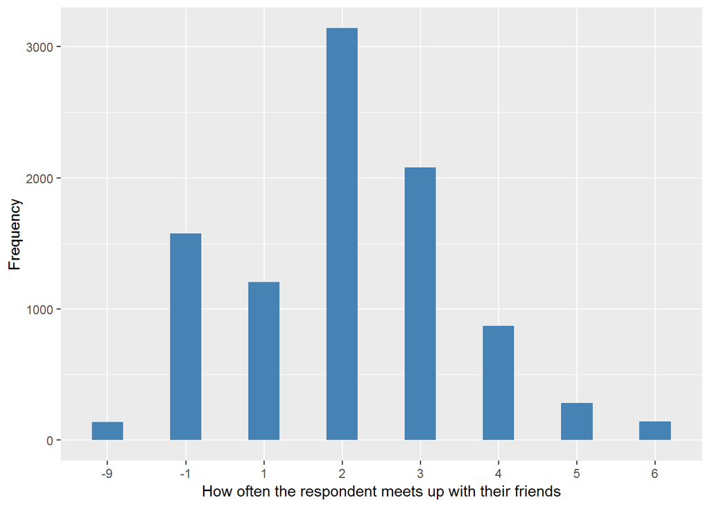

#### 2.1.2.2 Harmonisation algorithm

To compute the harmonize variable from the study-specific variable it has to be recoded as follows:

- `if scfrdg=1 then 1`
- `if scfrdg=2 then 2`
- `if scfrdg=3 then 3`
- `if scfrdg=4 or 5 then 4`
- `if scfrd=2 or scfrdg=6 then 5`
- `-9 into 995`
- `-1 into 996`
- `NA into 999`

**R script:**

```r
ELSA_ds_w2 <- tibble(id = ELSA_w2$id)

ELSA_w2$scfrd <- car::recode(as.vector(ELSA_w2$scfrd), "NA='-999'")
ELSA_w2$scfrdg <- car::recode(as.vector(ELSA_w2$scfrdg), "NA='-999'")

ELSA_ds_w2$f_cont_fr <- c(NA)  # I think it is required
for (i in 1:dim(ELSA_w2)[1]) {
    if (ELSA_w2$scfrdg[i] == 1) {
        ELSA_ds_w2$f_cont_fr[i] = 1
    } else if (ELSA_w2$scfrdg[i] == 2) {
        ELSA_ds_w2$f_cont_fr[i] = 2
    } else if (ELSA_w2$scfrdg[i] == 3) {
        ELSA_ds_w2$f_cont_fr[i] = 3
    } else if (ELSA_w2$scfrdg[i] %in% c(4, 5)) {
        ELSA_ds_w2$f_cont_fr[i] = 4
    } else if (ELSA_w2$scfrdg[i] == 6 | ELSA_w2$scfrd[i] == 2) {
        ELSA_ds_w2$f_cont_fr[i] = 5
    } else if (ELSA_w2$scfrdg[i] == -9 | ELSA_w2$scfrd[i] == -9) {
        ELSA_ds_w2$f_cont_fr[i] = 995
    } else if (ELSA_w2$scfrdg[i] == -1 | ELSA_w2$scfrd[i] == -1) {
        ELSA_ds_w2$f_cont_fr[i] = 996
    }
}

ELSA_ds_w2$f_cont_fr <- car::recode(as.vector(ELSA_ds_w2$f_cont_fr), "NA='999'")
ELSA_ds_w2$f_cont_fr <- labelled(ELSA_ds_w2$f_cont_fr, labels = c(`Daily/Almost daily` = 1,
    `Once a week` = 2, `Once or few times a month` = 3, `Less than once a month` = 4,
    `Never/No friends` = 5, Missing = 999, `Do not know` = 998, Refuse = 997,
    `Not applicable` = 996, `Don't answer` = 995, `Not attempt/not done/not yet recorded` = 994,
    `Disable to measure` = 993, Impute = 992, `CAPI/interviewer error` = 991))
```

#### 2.1.2.3 Statistics of the new harmonised variable

Frequency of face to face and phone contacts with friends

| Sample size | Missing values |
| --- | --- |
| 9432 | 1323 |

Category

|  | 1 | 2 | 3 | 4 | 5 |
| --- | --- | --- | --- | --- | --- |
| Frequency | 1204.00 | 3141.0 | 2077.00 | 1156.00 | 531.00 |
| Percentage | 12.77 | 33.3 | 22.02 | 12.26 | 5.63 |

Type of missing

|  | 991 | 992 | 993 | 994 | 995 | 996 | 997 | 998 | 999 | NA |
| --- | --- | --- | --- | --- | --- | --- | --- | --- | --- | --- |
| Frequency | 0 | 0 | 0 | 0 | 251.00 | 1072.00 | 0 | 0 | 0 | 0 |
| Percentage | 0 | 0 | 0 | 0 | 2.66 | 11.37 | 0 | 0 | 0 | 0 |

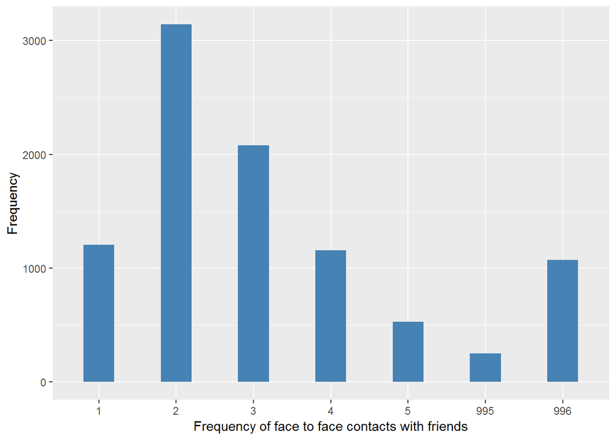

#### 2.1.2.4 Validation

### 2.1.3 Wave 3

#### 2.1.3.1 Study-specific variable description

| **Name** | `scfrd` | `scfrdg` |
| --- | --- | --- |
| **Label** | `do you have any friends` | `How often the respondent meets up with their friends` |
| **Table name** | `wave_3_elsa_data_v4` | `wave_3_elsa_data_v4` |
| **Categories** | `1 = Yes` `2 = No` | `1 = Three or more times a week` `2 = Once or twice a week` `3 = Once or twice a month` `4 = Every few months` `5 = Once or twice a year` `6 = Less than once a year or never` |
| **Missings** | `-9 = Not answered` `-1 = Item not applicable` | `-9 = Not answered` `-1 = Item not applicable` |
| **Description** |  |  |

scfrd

| Sample size | Missing values |
| --- | --- |
| 9771 | 1634 |

Type of missing

|  | -9 | -1 | NA |
| --- | --- | --- | --- |
| Frequency | 107.0 | 1527.00 | 0 |
| Percentage | 1.1 | 15.63 | 0 |

Category

|  | 1 | 2 |
| --- | --- | --- |
| Frequency | 7735.00 | 402.00 |
| Percentage | 79.16 | 4.11 |

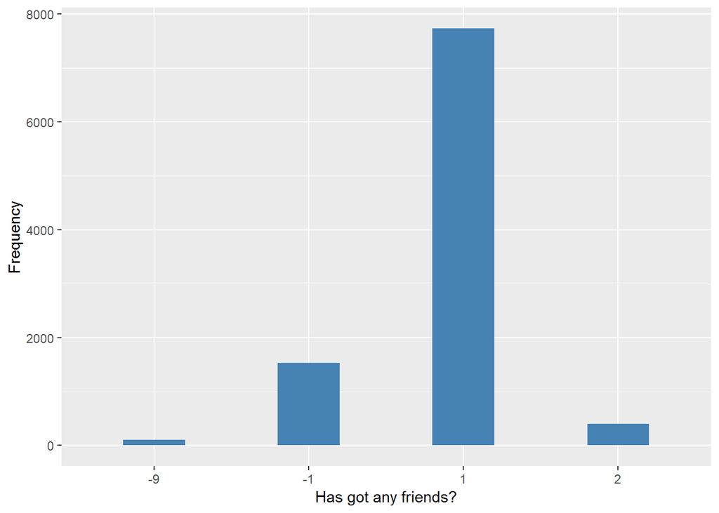

scfrdg

| Sample size | Missing values |
| --- | --- |
| 9771 | 2172 |

Type of missing

|  | -9 | -1 | NA |
| --- | --- | --- | --- |
| Frequency | 136.00 | 2036.00 | 0 |
| Percentage | 1.39 | 20.84 | 0 |

Category

|  | 1 | 2 | 3 | 4 | 5 | 6 |
| --- | --- | --- | --- | --- | --- | --- |
| Frequency | 1138.00 | 3132.00 | 2055.00 | 894.00 | 249.00 | 131.00 |
| Percentage | 11.65 | 32.05 | 21.03 | 9.15 | 2.55 | 1.34 |

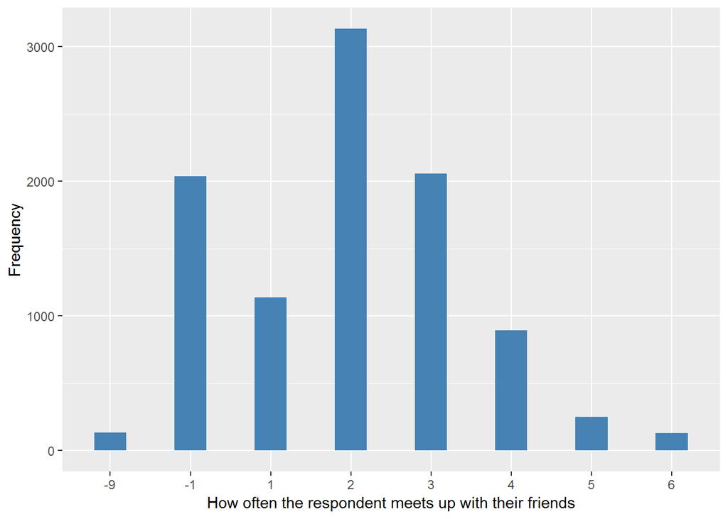

#### 2.1.3.2 Harmonisation algorithm

To compute the harmonize variable from the study-specific variable it has to be recoded as follows:

- `if scfrdg=1 then 1`
- `if scfrdg=2 then 2`
- `if scfrdg=3 then 3`
- `if scfrdg=4 or 5 then 4`
- `if scfrd=2 or scfrdg=6 then 5`
- `-9 into 995`
- `-1 into 996`
- `NA into 999`

**R script:**

```r
ELSA_ds_w3 <- tibble(id = ELSA_w3$id)

ELSA_w3$scfrd <- car::recode(as.vector(ELSA_w3$scfrd), "NA='-999'")
ELSA_w3$scfrdg <- car::recode(as.vector(ELSA_w3$scfrdg), "NA='-999'")

ELSA_ds_w3$f_cont_fr <- c(NA)  # I think it is required
for (i in 1:dim(ELSA_w3)[1]) {
    if (ELSA_w3$scfrdg[i] == 1) {
        ELSA_ds_w3$f_cont_fr[i] = 1
    } else if (ELSA_w3$scfrdg[i] == 2) {
        ELSA_ds_w3$f_cont_fr[i] = 2
    } else if (ELSA_w3$scfrdg[i] == 3) {
        ELSA_ds_w3$f_cont_fr[i] = 3
    } else if (ELSA_w3$scfrdg[i] %in% c(4, 5)) {
        ELSA_ds_w3$f_cont_fr[i] = 4
    } else if (ELSA_w3$scfrdg[i] == 6 | ELSA_w3$scfrd[i] == 2) {
        ELSA_ds_w3$f_cont_fr[i] = 5
    } else if (ELSA_w3$scfrdg[i] == -9 | ELSA_w3$scfrd[i] == -9) {
        ELSA_ds_w3$f_cont_fr[i] = 995
    } else if (ELSA_w3$scfrdg[i] == -1 | ELSA_w3$scfrd[i] == -1) {
        ELSA_ds_w3$f_cont_fr[i] = 996
    }
}

ELSA_ds_w3$f_cont_fr <- car::recode(as.vector(ELSA_ds_w3$f_cont_fr), "NA='999'")
ELSA_ds_w3$f_cont_fr <- labelled(ELSA_ds_w3$f_cont_fr, labels = c(`Daily/Almost daily` = 1,
    `Once a week` = 2, `Once or few times a month` = 3, `Less than once a month` = 4,
    `Never/No friends` = 5, Missing = 999, `Do not know` = 998, Refuse = 997,
    `Not applicable` = 996, `Don't answer` = 995, `Not attempt/not done/not yet recorded` = 994,
    `Disable to measure` = 993, Impute = 992, `CAPI/interviewer error` = 991))
```

#### 2.1.3.3 Statistics of the new harmonised variable

Frequency of face to face and phone contacts with friends

| Sample size | Missing values |
| --- | --- |
| 9771 | 1770 |

Category

|  | 1 | 2 | 3 | 4 | 5 |
| --- | --- | --- | --- | --- | --- |
| Frequency | 1138.00 | 3132.00 | 2055.00 | 1143.0 | 533.00 |
| Percentage | 11.65 | 32.05 | 21.03 | 11.7 | 5.45 |

Type of missing

|  | 991 | 992 | 993 | 994 | 995 | 996 | 997 | 998 | 999 | NA |
| --- | --- | --- | --- | --- | --- | --- | --- | --- | --- | --- |
| Frequency | 0 | 0 | 0 | 0 | 243.00 | 1527.00 | 0 | 0 | 0 | 0 |
| Percentage | 0 | 0 | 0 | 0 | 2.49 | 15.63 | 0 | 0 | 0 | 0 |

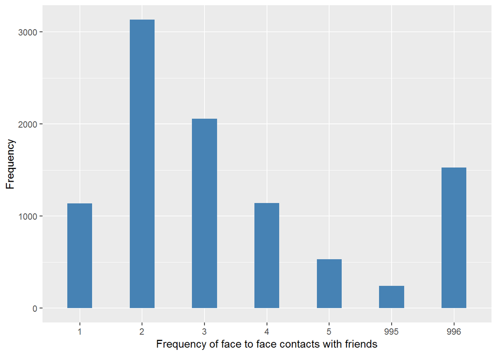

#### 2.1.3.4 Validation

### 2.1.4 Wave 4

#### 2.1.4.1 Study-specific variable description

| **Name** | `scfrd` | `scfrdg` |
| --- | --- | --- |
| **Label** | `do you have any friends` | `How often the respondent meets up with their friends` |
| **Table name** | `wave_4_elsa_data_v3` | `wave_4_elsa_data_v3` |
| **Categories** | `1 = Yes` `2 = No` | `1 = Three or more times a week` `2 = Once or twice a week` `3 = Once or twice a month` `4 = Every few months` `5 = Once or twice a year` `6 = Less than once a year or never` |
| **Missings** | `-9 = Not answered` `-1 = Item not applicable` | `-9 = Not answered` `-8 = Don't know` `-1 = Item not applicable` |
| **Description** |  |  |

scfrd

| Sample size | Missing values |
| --- | --- |
| 11050 | 1823 |

Type of missing

|  | -9 | -1 | NA |
| --- | --- | --- | --- |
| Frequency | 115.00 | 1708.00 | 0 |
| Percentage | 1.04 | 15.46 | 0 |

Category

|  | 1 | 2 |
| --- | --- | --- |
| Frequency | 8756.00 | 471.00 |
| Percentage | 79.24 | 4.26 |

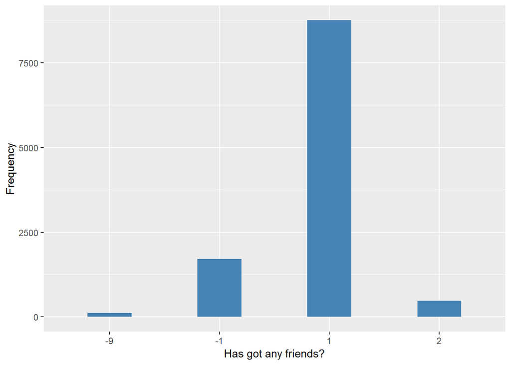

scfrdg

| Sample size | Missing values |
| --- | --- |
| 11050 | 2410 |

Type of missing

|  | -9 | -1 | -8 | NA |
| --- | --- | --- | --- | --- |
| Frequency | 116.00 | 2294.00 | 0 | 0 |
| Percentage | 1.05 | 20.76 | 0 | 0 |

Category

|  | 1 | 2 | 3 | 4 | 5 | 6 |
| --- | --- | --- | --- | --- | --- | --- |
| Frequency | 1316.00 | 3489.00 | 2363.00 | 976.00 | 329.00 | 167.00 |
| Percentage | 11.91 | 31.57 | 21.38 | 8.83 | 2.98 | 1.51 |

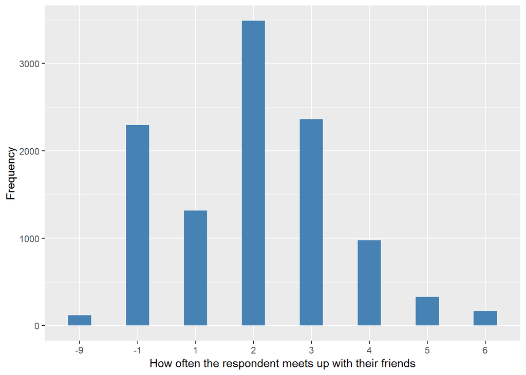

#### 2.1.4.2 Harmonisation algorithm

To compute the harmonize variable from the study-specific variable it has to be recoded as follows:

- `if scfrdg=1 then 1`
- `if scfrdg=2 then 2`
- `if scfrdg=3 then 3`
- `if scfrdg=4 or 5 then 4`
- `if scfrd=2 or scfrdg=6 then 5`
- `-8 into 998`
- `-9 into 995`
- `-1 into 996`
- `NA into 999`

**R script:**

```r
ELSA_ds_w4 <- tibble(id = ELSA_w4$id)

ELSA_w4$scfrd <- car::recode(as.vector(ELSA_w4$scfrd), "NA='-999'")
ELSA_w4$scfrdg <- car::recode(as.vector(ELSA_w4$scfrdg), "NA='-999'")

ELSA_ds_w4$f_cont_fr <- c(NA)  # I think it is required
for (i in 1:dim(ELSA_w4)[1]) {
    if (ELSA_w4$scfrdg[i] == 1) {
        ELSA_ds_w4$f_cont_fr[i] = 1
    } else if (ELSA_w4$scfrdg[i] == 2) {
        ELSA_ds_w4$f_cont_fr[i] = 2
    } else if (ELSA_w4$scfrdg[i] == 3) {
        ELSA_ds_w4$f_cont_fr[i] = 3
    } else if (ELSA_w4$scfrdg[i] %in% c(4, 5)) {
        ELSA_ds_w4$f_cont_fr[i] = 4
    } else if (ELSA_w4$scfrdg[i] == 6 | ELSA_w4$scfrd[i] == 2) {
        ELSA_ds_w4$f_cont_fr[i] = 5
    } else if (ELSA_w4$scfrdg[i] == -8 | ELSA_w4$scfrd[i] == -8) {
        ELSA_ds_w4$f_cont_fr[i] = 998
    } else if (ELSA_w4$scfrdg[i] == -9 | ELSA_w4$scfrd[i] == -9) {
        ELSA_ds_w4$f_cont_fr[i] = 995
    } else if (ELSA_w4$scfrdg[i] == -1 | ELSA_w4$scfrd[i] == -1) {
        ELSA_ds_w4$f_cont_fr[i] = 996
    }
}

ELSA_ds_w4$f_cont_fr <- car::recode(as.vector(ELSA_ds_w4$f_cont_fr), "NA='999'")
ELSA_ds_w4$f_cont_fr <- labelled(ELSA_ds_w4$f_cont_fr, labels = c(`Daily/Almost daily` = 1,
    `Once a week` = 2, `Once or few times a month` = 3, `Less than once a month` = 4,
    `Never/No friends` = 5, Missing = 999, `Do not know` = 998, Refuse = 997,
    `Not applicable` = 996, `Don't answer` = 995, `Not attempt/not done/not yet recorded` = 994,
    `Disable to measure` = 993, Impute = 992, `CAPI/interviewer error` = 991))
```

#### 2.1.4.3 Statistics of the new harmonised variable

Frequency of face to face and phone contacts with friends

| Sample size | Missing values |
| --- | --- |
| 11050 | 1939 |

Category

|  | 1 | 2 | 3 | 4 | 5 |
| --- | --- | --- | --- | --- | --- |
| Frequency | 1316.00 | 3489.00 | 2363.00 | 1305.00 | 638.00 |
| Percentage | 11.91 | 31.57 | 21.38 | 11.81 | 5.77 |

Type of missing

|  | 991 | 992 | 993 | 994 | 995 | 996 | 997 | 998 | 999 | NA |
| --- | --- | --- | --- | --- | --- | --- | --- | --- | --- | --- |
| Frequency | 0 | 0 | 0 | 0 | 231.00 | 1708.00 | 0 | 0 | 0 | 0 |
| Percentage | 0 | 0 | 0 | 0 | 2.09 | 15.46 | 0 | 0 | 0 | 0 |

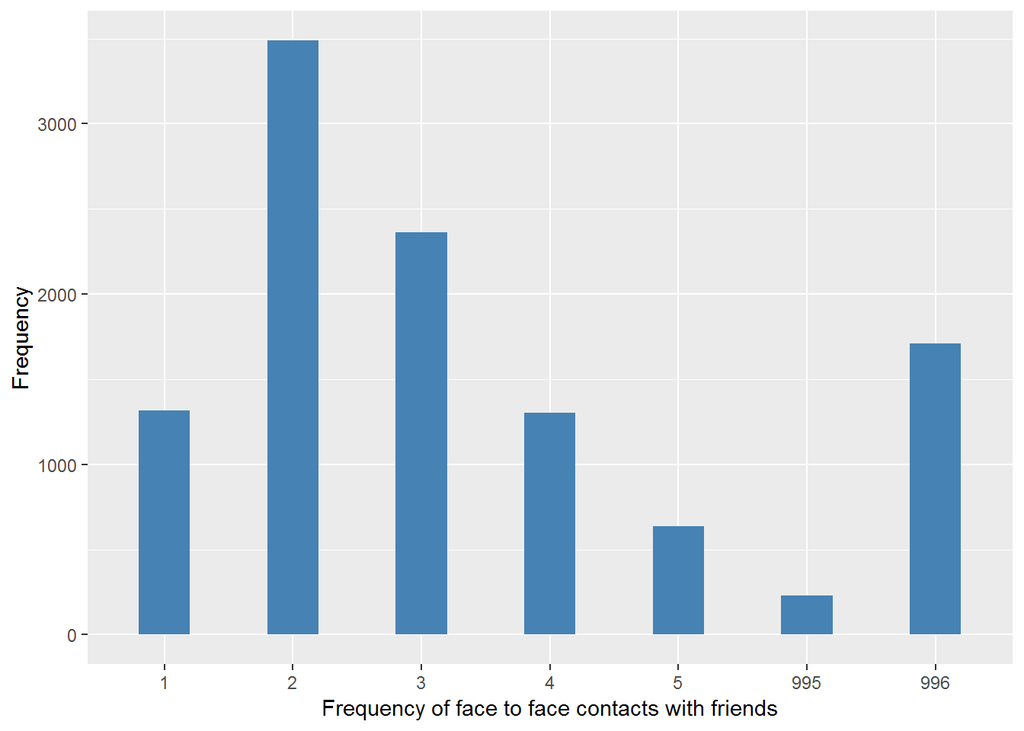

#### 2.1.4.4 Validation

### 2.1.5 Wave 5

#### 2.1.5.1 Study-specific variable description

| **Name** | `scfrd` | `scfrdg` |
| --- | --- | --- |
| **Label** | `do you have any friends` | `How often the respondent meets up with their friends` |
| **Table name** | `wave_5_elsa_data_v4` | `wave_5_elsa_data_v4` |
| **Categories** | `1 = Yes` `2 = No` | `1 = Three or more times a week` `2 = Once or twice a week` `3 = Once or twice a month` `4 = Every few months` `5 = Once or twice a year` `6 = Less than once a year or never` |
| **Missings** | `-9 = Not answered` `-2 = Schedule not applicable` `-1 = Item not applicable` | `-9 = Not answered` `-8 = Don't know` `-2 = Schedule not applicable` `-1 = Item not applicable` |
| **Description** |  |  |

scfrd

| Sample size | Missing values |
| --- | --- |
| 10274 | 1360 |

Type of missing

|  | -9 | -1 | -2 | NA |
| --- | --- | --- | --- | --- |
| Frequency | 116.00 | 0 | 1244.00 | 0 |
| Percentage | 1.13 | 0 | 12.11 | 0 |

Category

|  | 1 | 2 |
| --- | --- | --- |
| Frequency | 8382.00 | 532.00 |
| Percentage | 81.58 | 5.18 |

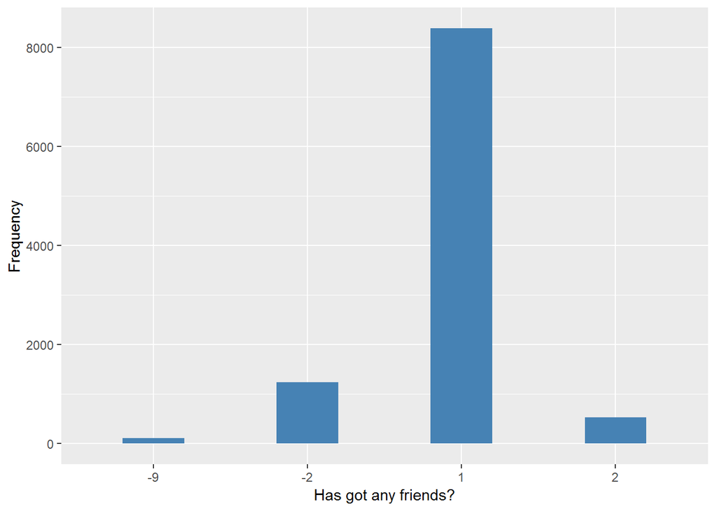

scfrdg

| Sample size | Missing values |
| --- | --- |
| 10274 | 2009 |

Type of missing

|  | -9 | -8 | -2 | -1 | NA |
| --- | --- | --- | --- | --- | --- |
| Frequency | 117.00 | 0 | 1244.00 | 648.00 | 0 |
| Percentage | 1.14 | 0 | 12.11 | 6.31 | 0 |

Category

|  | 1 | 2 | 3 | 4 | 5 | 6 |
| --- | --- | --- | --- | --- | --- | --- |
| Frequency | 1236.00 | 3378.00 | 2196.00 | 979.00 | 323.00 | 153.00 |
| Percentage | 12.03 | 32.88 | 21.37 | 9.53 | 3.14 | 1.49 |

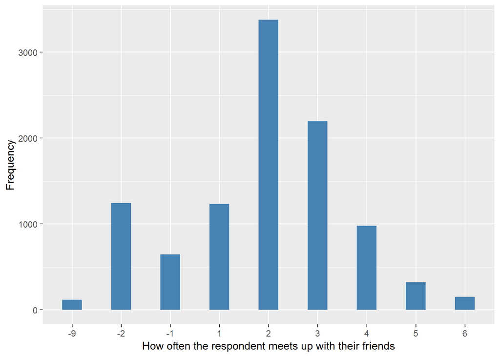

#### 2.1.5.2 Harmonisation algorithm

To compute the harmonize variable from the study-specific variable it has to be recoded as follows:

- `if scfrdg=1 then 1`
- `if scfrdg=2 then 2`
- `if scfrdg=3 then 3`
- `if scfrdg=4 or 5 then 4`
- `if scfrd=2 or scfrdg=6 then 5`
- `-8 into 998`
- `-9 into 995`
- `-1 or -2 into 996`
- `NA into 999`

**R script:**

```r
ELSA_ds_w5 <- tibble(id = ELSA_w5$id)

ELSA_w5$scfrd <- car::recode(as.vector(ELSA_w5$scfrd), "NA='-999'")
ELSA_w5$scfrdg <- car::recode(as.vector(ELSA_w5$scfrdg), "NA='-999'")

ELSA_ds_w5$f_cont_fr <- c(NA)  # I think it is required
for (i in 1:dim(ELSA_w5)[1]) {
    if (ELSA_w5$scfrdg[i] == 1) {
        ELSA_ds_w5$f_cont_fr[i] = 1
    } else if (ELSA_w5$scfrdg[i] == 2) {
        ELSA_ds_w5$f_cont_fr[i] = 2
    } else if (ELSA_w5$scfrdg[i] == 3) {
        ELSA_ds_w5$f_cont_fr[i] = 3
    } else if (ELSA_w5$scfrdg[i] %in% c(4, 5)) {
        ELSA_ds_w5$f_cont_fr[i] = 4
    } else if (ELSA_w5$scfrdg[i] == 6 | ELSA_w5$scfrd[i] == 2) {
        ELSA_ds_w5$f_cont_fr[i] = 5
    } else if (ELSA_w5$scfrdg[i] == -8 | ELSA_w5$scfrd[i] == -8) {
        ELSA_ds_w5$f_cont_fr[i] = 998
    } else if (ELSA_w5$scfrdg[i] == -9 | ELSA_w5$scfrd[i] == -9) {
        ELSA_ds_w5$f_cont_fr[i] = 995
    } else if (ELSA_w5$scfrdg[i] %in% c(-1, -2) | ELSA_w5$scfrd[i] %in% c(-1,
        -2)) {
        ELSA_ds_w5$f_cont_fr[i] = 996
    }
}

ELSA_ds_w5$f_cont_fr <- car::recode(as.vector(ELSA_ds_w5$f_cont_fr), "NA='999'")
ELSA_ds_w5$f_cont_fr <- labelled(ELSA_ds_w5$f_cont_fr, labels = c(`Daily/Almost daily` = 1,
    `Once a week` = 2, `Once or few times a month` = 3, `Less than once a month` = 4,
    `Never/No friends` = 5, Missing = 999, `Do not know` = 998, Refuse = 997,
    `Not applicable` = 996, `Don't answer` = 995, `Not attempt/not done/not yet recorded` = 994,
    `Disable to measure` = 993, Impute = 992, `CAPI/interviewer error` = 991))
```

#### 2.1.5.3 Statistics of the new harmonised variable

Frequency of face to face and phone contacts with friends

| Sample size | Missing values |
| --- | --- |
| 10274 | 1477 |

Category

|  | 1 | 2 | 3 | 4 | 5 |
| --- | --- | --- | --- | --- | --- |
| Frequency | 1236.00 | 3378.00 | 2196.00 | 1302.00 | 685.00 |
| Percentage | 12.03 | 32.88 | 21.37 | 12.67 | 6.67 |

Type of missing

|  | 991 | 992 | 993 | 994 | 995 | 996 | 997 | 998 | 999 | NA |
| --- | --- | --- | --- | --- | --- | --- | --- | --- | --- | --- |
| Frequency | 0 | 0 | 0 | 0 | 233.00 | 1244.00 | 0 | 0 | 0 | 0 |
| Percentage | 0 | 0 | 0 | 0 | 2.27 | 12.11 | 0 | 0 | 0 | 0 |

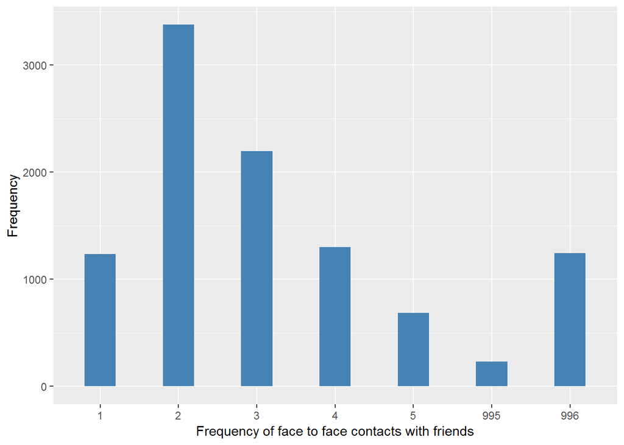

#### 2.1.5.4 Validation

### 2.1.6 Wave 6

#### 2.1.6.1 Study-specific variable description

| **Name** | `scfrd` | `scfrdg` |
| --- | --- | --- |
| **Label** | `do you have any friends` | `How often the respondent meets up with their friends` |
| **Table name** | `wave_6_elsa_data_v2` | `wave_6_elsa_data_v2` |
| **Categories** | `1 = Yes` `2 = No` | `1 = Three or more times a week` `2 = Once or twice a week` `3 = Once or twice a month` `4 = Every few months` `5 = Once or twice a year` `6 = Less than once a year or never` |
| **Missings** | `-9 = Not answered` `-2 = Schedule not applicable` `-1 = Item not applicable` | `-9 = Not answered` `-8 = Don't know` `-2 = Schedule not applicable` `-1 = Item not applicable` |
| **Description** |  |  |

scfrd

| Sample size | Missing values |
| --- | --- |
| 10601 | 1656 |

Type of missing

|  | -9 | -1 | -2 | NA |
| --- | --- | --- | --- | --- |
| Frequency | 52.00 | 0 | 1604.00 | 0 |
| Percentage | 0.49 | 0 | 15.13 | 0 |

Category

|  | 1 | 2 |
| --- | --- | --- |
| Frequency | 8383.00 | 562.0 |
| Percentage | 79.08 | 5.3 |

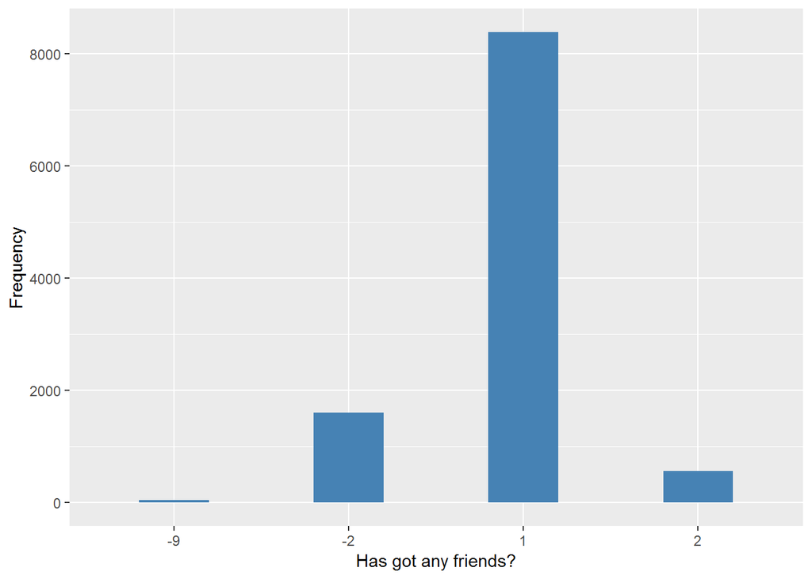

scfrdg

| Sample size | Missing values |
| --- | --- |
| 10601 | 2341 |

Type of missing

|  | -9 | -8 | -2 | -1 | NA |
| --- | --- | --- | --- | --- | --- |
| Frequency | 123.00 | 0 | 1604.00 | 614.00 | 0 |
| Percentage | 1.16 | 0 | 15.13 | 5.79 | 0 |

Category

|  | 1 | 2 | 3 | 4 | 5 | 6 |
| --- | --- | --- | --- | --- | --- | --- |
| Frequency | 1174.00 | 3290.00 | 2296.00 | 997.0 | 328.00 | 175.00 |
| Percentage | 11.07 | 31.03 | 21.66 | 9.4 | 3.09 | 1.65 |

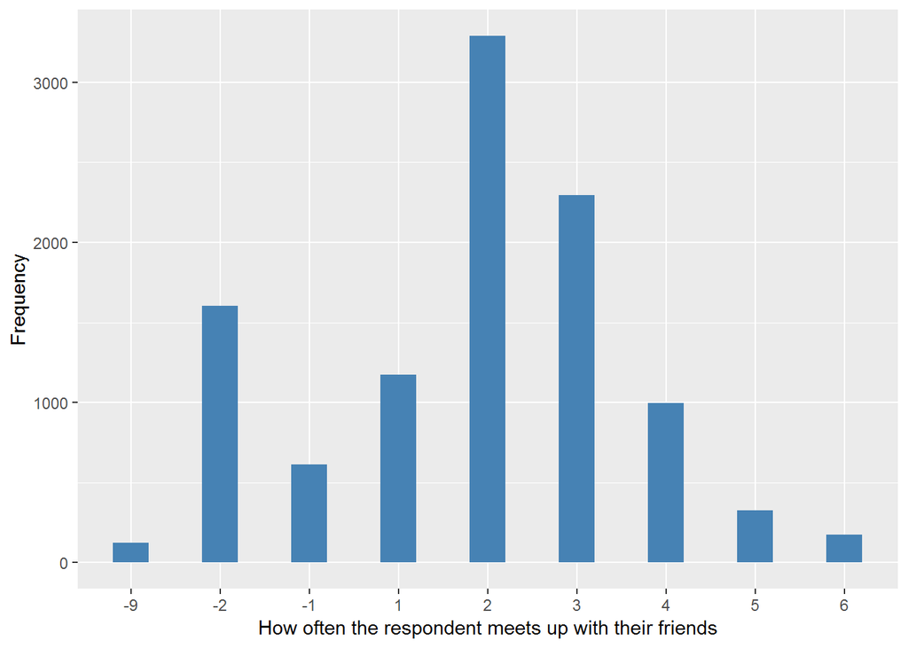

#### 2.1.6.2 Harmonisation algorithm

To compute the harmonize variable from the study-specific variable it has to be recoded as follows:

- `if scfrdg=1 then 1`
- `if scfrdg=2 then 2`
- `if scfrdg=3 then 3`
- `if scfrdg=4 or 5 then 4`
- `if scfrd=2 or scfrdg=6 then 5`
- `-8 into 998`
- `-9 into 995`
- `-1 or -2 into 996`
- `NA into 999`

**R script:**

```r
ELSA_ds_w6 <- tibble(id = ELSA_w6$id)

ELSA_w6$scfrd <- car::recode(as.vector(ELSA_w6$scfrd), "NA='-999'")
ELSA_w6$scfrdg <- car::recode(as.vector(ELSA_w6$scfrdg), "NA='-999'")

ELSA_ds_w6$f_cont_fr <- c(NA)  # I think it is required
for (i in 1:dim(ELSA_w6)[1]) {
    if (ELSA_w6$scfrdg[i] == 1) {
        ELSA_ds_w6$f_cont_fr[i] = 1
    } else if (ELSA_w6$scfrdg[i] == 2) {
        ELSA_ds_w6$f_cont_fr[i] = 2
    } else if (ELSA_w6$scfrdg[i] == 3) {
        ELSA_ds_w6$f_cont_fr[i] = 3
    } else if (ELSA_w6$scfrdg[i] %in% c(4, 5)) {
        ELSA_ds_w6$f_cont_fr[i] = 4
    } else if (ELSA_w6$scfrdg[i] == 6 | ELSA_w6$scfrd[i] == 2) {
        ELSA_ds_w6$f_cont_fr[i] = 5
    } else if (ELSA_w6$scfrdg[i] == -8 | ELSA_w6$scfrd[i] == -8) {
        ELSA_ds_w6$f_cont_fr[i] = 998
    } else if (ELSA_w6$scfrdg[i] == -9 | ELSA_w6$scfrd[i] == -9) {
        ELSA_ds_w6$f_cont_fr[i] = 995
    } else if (ELSA_w6$scfrdg[i] %in% c(-1, -2) | ELSA_w6$scfrd[i] %in% c(-1,
        -2)) {
        ELSA_ds_w6$f_cont_fr[i] = 996
    }
}

ELSA_ds_w6$f_cont_fr <- car::recode(as.vector(ELSA_ds_w6$f_cont_fr), "NA='999'")
ELSA_ds_w6$f_cont_fr <- labelled(ELSA_ds_w6$f_cont_fr, labels = c(`Daily/Almost daily` = 1,
    `Once a week` = 2, `Once or few times a month` = 3, `Less than once a month` = 4,
    `Never/No friends` = 5, Missing = 999, `Do not know` = 998, Refuse = 997,
    `Not applicable` = 996, `Don't answer` = 995, `Not attempt/not done/not yet recorded` = 994,
    `Disable to measure` = 993, Impute = 992, `CAPI/interviewer error` = 991))
```

#### 2.1.6.3 Statistics of the new harmonised variable

Frequency of face to face and phone contacts with friends

| Sample size | Missing values |
| --- | --- |
| 10601 | 1779 |

Category

|  | 1 | 2 | 3 | 4 | 5 |
| --- | --- | --- | --- | --- | --- |
| Frequency | 1174.00 | 3290.00 | 2296.00 | 1325.0 | 737.00 |
| Percentage | 11.07 | 31.03 | 21.66 | 12.5 | 6.95 |

Type of missing

|  | 991 | 992 | 993 | 994 | 995 | 996 | 997 | 998 | 999 | NA |
| --- | --- | --- | --- | --- | --- | --- | --- | --- | --- | --- |
| Frequency | 0 | 0 | 0 | 0 | 175.00 | 1604.00 | 0 | 0 | 0 | 0 |
| Percentage | 0 | 0 | 0 | 0 | 1.65 | 15.13 | 0 | 0 | 0 | 0 |

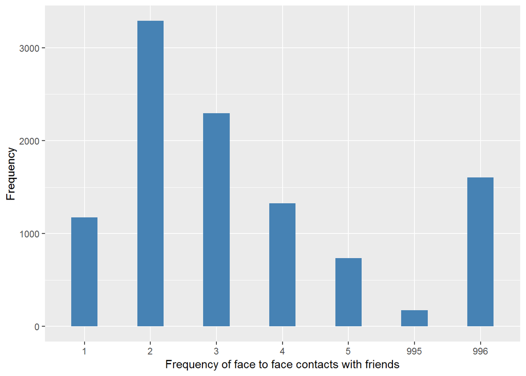

#### 2.1.6.4 Validation

### 2.1.7 Wave 7

#### 2.1.7.1 Study-specific variable description

| **Name** | `scfrd` | `scfrdh` |
| --- | --- | --- |
| **Label** | `do you have any friends` | `How often the respondent meets up with their friends` |
| **Table name** | `wave_7_elsa_data` | `wave_7_elsa_data` |
| **Categories** | `1 = Yes` `2 = No` | `1 = Three or more times a week` `2 = Once or twice a week` `3 = Once or twice a month` `4 = Every few months` `5 = Once or twice a year` `6 = Less than once a year or never` |
| **Missings** | `-9 = Not answered` `-2 = Schedule not applicable` `-1 = Item not applicable` | `-9 = Not answered` `-8 = Don't know` `-2 = Schedule not applicable` `-1 = Item not applicable` |
| **Description** |  |  |

scfrd

| Sample size | Missing values |
| --- | --- |
| 9666 | 1542 |

Type of missing

|  | -9 | -1 | -2 | NA |
| --- | --- | --- | --- | --- |
| Frequency | 73.00 | 0 | 1469.0 | 0 |
| Percentage | 0.76 | 0 | 15.2 | 0 |

Category

|  | 1 | 2 |
| --- | --- | --- |
| Frequency | 7620.00 | 504.00 |
| Percentage | 78.83 | 5.21 |

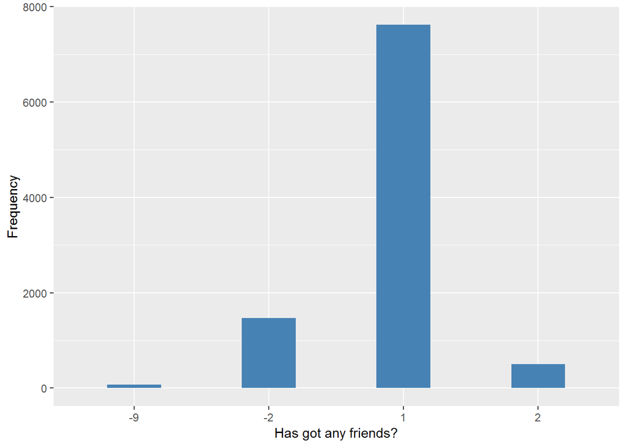

scfrdh

| Sample size | Missing values |
| --- | --- |
| 9666 | 2192 |

Type of missing

|  | -9 | -8 | -2 | -1 | NA |
| --- | --- | --- | --- | --- | --- |
| Frequency | 146.00 | 0 | 1469.0 | 577.00 | 0 |
| Percentage | 1.51 | 0 | 15.2 | 5.97 | 0 |

Category

|  | 1 | 2 | 3 | 4 | 5 | 6 |
| --- | --- | --- | --- | --- | --- | --- |
| Frequency | 1060.00 | 3026.00 | 2079.00 | 906.00 | 276.00 | 127.00 |
| Percentage | 10.97 | 31.31 | 21.51 | 9.37 | 2.86 | 1.31 |

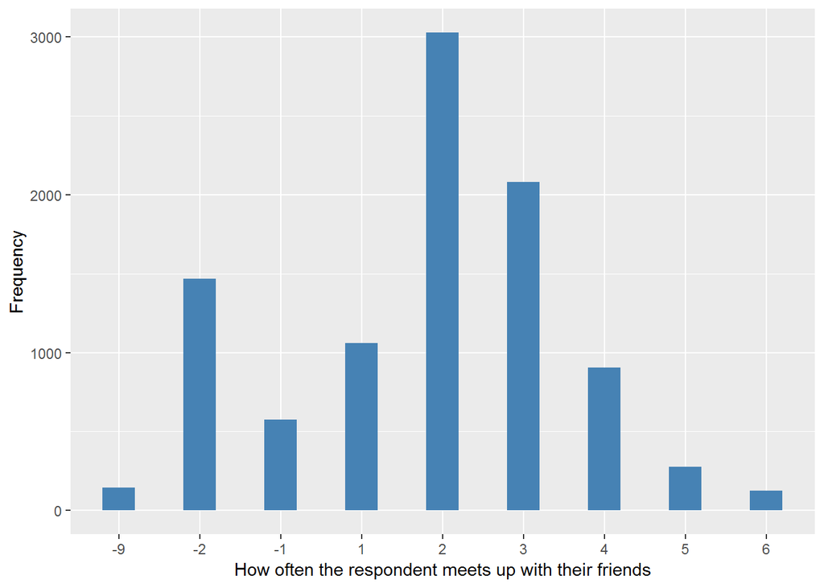

#### 2.1.7.2 Harmonisation algorithm

To compute the harmonize variable from the study-specific variable it has to be recoded as follows:

- `if scfrdh=1 then 1`
- `if scfrdh=2 then 2`
- `if scfrdh=3 then 3`
- `if scfrdh=4 or 5 then 4`
- `if scfrd=2 or scfrdh=6 then 5`
- `-8 into 998`
- `-9 into 995`
- `-1 or -2 into 996`
- `NA into 999`

**R script:**

```r
ELSA_ds_w7 <- tibble(id = ELSA_w7$id)

ELSA_w7$scfrd <- car::recode(as.vector(ELSA_w7$scfrd), "NA='-999'")
ELSA_w7$scfrdh <- car::recode(as.vector(ELSA_w7$scfrdh), "NA='-999'")

ELSA_ds_w7$f_cont_fr <- c(NA)  # I think it is required
for (i in 1:dim(ELSA_w7)[1]) {
    if (ELSA_w7$scfrdh[i] == 1) {
        ELSA_ds_w7$f_cont_fr[i] = 1
    } else if (ELSA_w7$scfrdh[i] == 2) {
        ELSA_ds_w7$f_cont_fr[i] = 2
    } else if (ELSA_w7$scfrdh[i] == 3) {
        ELSA_ds_w7$f_cont_fr[i] = 3
    } else if (ELSA_w7$scfrdh[i] %in% c(4, 5)) {
        ELSA_ds_w7$f_cont_fr[i] = 4
    } else if (ELSA_w7$scfrdh[i] == 6 | ELSA_w7$scfrd[i] == 2) {
        ELSA_ds_w7$f_cont_fr[i] = 5
    } else if (ELSA_w7$scfrdh[i] == -8 | ELSA_w7$scfrd[i] == -8) {
        ELSA_ds_w7$f_cont_fr[i] = 998
    } else if (ELSA_w7$scfrdh[i] == -9 | ELSA_w7$scfrd[i] == -9) {
        ELSA_ds_w7$f_cont_fr[i] = 995
    } else if (ELSA_w7$scfrdh[i] %in% c(-1, -2) | ELSA_w7$scfrd[i] %in% c(-1,
        -2)) {
        ELSA_ds_w7$f_cont_fr[i] = 996
    }
}

ELSA_ds_w7$f_cont_fr <- car::recode(as.vector(ELSA_ds_w7$f_cont_fr), "NA='999'")
ELSA_ds_w7$f_cont_fr <- labelled(ELSA_ds_w7$f_cont_fr, labels = c(`Daily/Almost daily` = 1,
    `Once a week` = 2, `Once or few times a month` = 3, `Less than once a month` = 4,
    `Never/No friends` = 5, Missing = 999, `Do not know` = 998, Refuse = 997,
    `Not applicable` = 996, `Don't answer` = 995, `Not attempt/not done/not yet recorded` = 994,
    `Disable to measure` = 993, Impute = 992, `CAPI/interviewer error` = 991))
```

#### 2.1.7.3 Statistics of the new harmonised variable

Frequency of face to face and phone contacts with friends

| Sample size | Missing values |
| --- | --- |
| 9666 | 1688 |

Category

|  | 1 | 2 | 3 | 4 | 5 |
| --- | --- | --- | --- | --- | --- |
| Frequency | 1060.00 | 3026.00 | 2079.00 | 1182.00 | 631.00 |
| Percentage | 10.97 | 31.31 | 21.51 | 12.23 | 6.53 |

Type of missing

|  | 991 | 992 | 993 | 994 | 995 | 996 | 997 | 998 | 999 | NA |
| --- | --- | --- | --- | --- | --- | --- | --- | --- | --- | --- |
| Frequency | 0 | 0 | 0 | 0 | 219.00 | 1469.0 | 0 | 0 | 0 | 0 |
| Percentage | 0 | 0 | 0 | 0 | 2.27 | 15.2 | 0 | 0 | 0 | 0 |

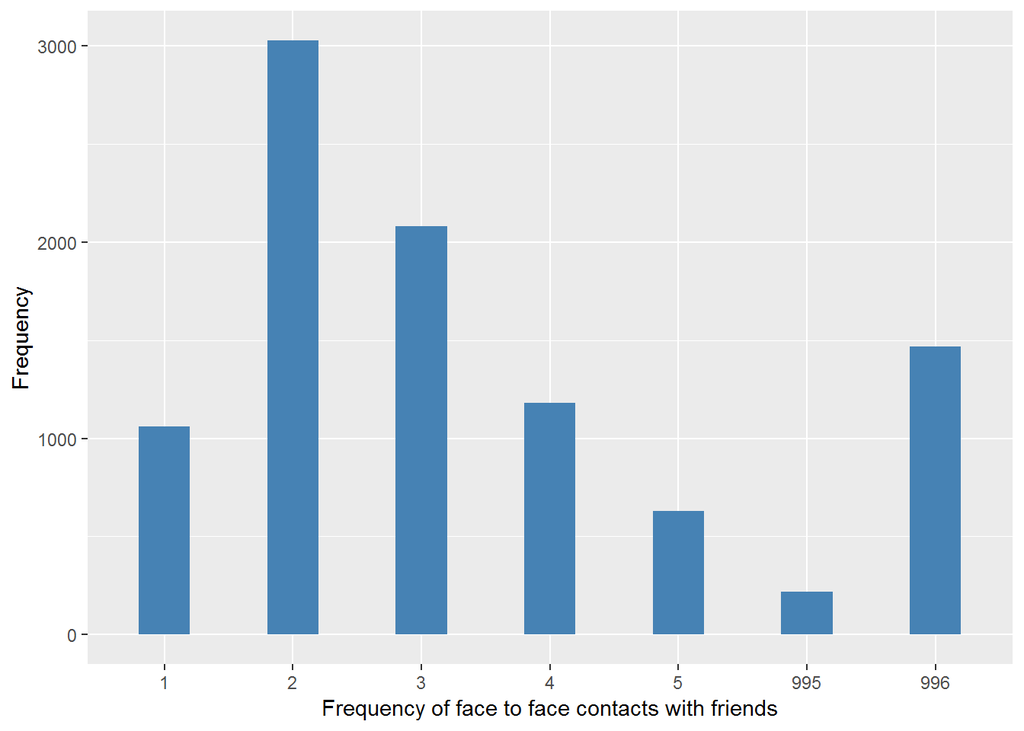

#### 2.1.7.4 Validation

## 2.2 Summary of descriptive statistics of the harmonised variable accross populations and waves

Two tables are generated:

1. Percentages of categories in each harmonised variable.
2. Frequencies and percentages of individuals with different trajectories. To avoid too large table, Only trajectories with percentages larger than 0.3 are shown.

Frequency of face to face and phone contacts with friends

| val | label | W1 | W2 | W3 | W4 | W5 | W6 | W7 |
| --- | --- | --- | --- | --- | --- | --- | --- | --- |
| 1 | Daily/Almost daily | 13.6 | 12.77 | 11.65 | 11.91 | 12.03 | 11.07 | 10.97 |
| 2 | Once a week | 34.52 | 33.3 | 32.05 | 31.57 | 32.88 | 31.03 | 31.31 |
| 3 | Once or few times a month | 20.12 | 22.02 | 21.03 | 21.38 | 21.37 | 21.66 | 21.51 |
| 4 | Less than once a month | 11.67 | 12.26 | 11.7 | 11.81 | 12.67 | 12.5 | 12.23 |
| 5 | Never/No friends | 6.13 | 5.63 | 5.45 | 5.77 | 6.67 | 6.95 | 6.53 |
| 991 | CAPI interviewer error | 0 | 0 | 0 | 0 | 0 | 0 | 0 |
| 992 | Impute | 0 | 0 | 0 | 0 | 0 | 0 | 0 |
| 993 | Disable to measure | 0 | 0 | 0 | 0 | 0 | 0 | 0 |
| 994 | Not attempt not done | 0 | 0 | 0 | 0 | 0 | 0 | 0 |
| 995 | Does not answer | 4.8 | 2.66 | 2.49 | 2.09 | 2.27 | 1.65 | 2.27 |
| 996 | Not applicable | 9.16 | 11.37 | 15.63 | 15.46 | 12.11 | 15.13 | 15.2 |
| 997 | Refuse | 0 | 0 | 0 | 0 | 0 | 0 | 0 |
| 998 | Do not know | 0 | 0 | 0 | 0 | 0 | 0 | 0 |
| 999 | Missing | 0 | 0 | 0 | 0 | 0 | 0 | 0 |
| NA | NA | 0 | 0 | 0 | 0 | 0 | 0 | 0 |
| n | sample size | 12099 | 9432 | 9771 | 11050 | 10274 | 10601 | 9666 |

|  | val | frq | raw.prc |
| --- | --- | --- | --- |
| 209 | 11NANANANANA | 77 | 0.42 |
| 406 | 12NANANANANA | 68 | 0.37 |
| 660 | 1NANANANANANA | 356 | 1.93 |
| 852 | 21NANANANANA | 58 | 0.31 |
| 980 | 2222222 | 165 | 0.89 |
| 1139 | 222NANANANA | 102 | 0.55 |
| 1385 | 22NANANANANA | 249 | 1.35 |
| 1697 | 23NANANANANA | 76 | 0.41 |
| 2058 | 2NANANANANANA | 750 | 4.06 |
| 2367 | 32NANANANANA | 57 | 0.31 |
| 2747 | 33NANANANANA | 117 | 0.63 |
| 3125 | 3NANANANANANA | 421 | 2.28 |
| 3676 | 44NANANANANA | 64 | 0.35 |
| 3822 | 4NANANANANANA | 281 | 1.52 |
| 4113 | 5NANANANANANA | 231 | 1.25 |
| 4283 | NA2NANANANANA | 65 | 0.35 |
| 4769 | NANA2NANANANA | 93 | 0.50 |
| 4936 | NANA3NANANANA | 72 | 0.39 |
| 5178 | NANANA1NANANA | 55 | 0.30 |
| 5202 | NANANA2222 | 154 | 0.83 |
| 5298 | NANANA2NANANA | 125 | 0.68 |
| 5414 | NANANA3NANANA | 78 | 0.42 |
| 5691 | NANANANANA22 | 130 | 0.70 |
| 5692 | NANANANANA23 | 56 | 0.30 |
| 5695 | NANANANANA2NA | 82 | 0.44 |
| 5698 | NANANANANA33 | 110 | 0.59 |
| 5701 | NANANANANA3NA | 75 | 0.41 |
| 5705 | NANANANANA44 | 68 | 0.37 |
| 5714 | NANANANANANA1 | 73 | 0.39 |
| 5715 | NANANANANANA2 | 176 | 0.95 |
| 5716 | NANANANANANA3 | 148 | 0.80 |
| 5717 | NANANANANANA4 | 80 | 0.43 |
| 5719 | NANANANANANANA | 1732 | 9.37 |

# 3 Quality estimation